# Prediction Assignment Writeup

Antonio Serrano

May 29, 2016

- Index:
  - Abstract
  - 1. Introduction
  - 2. Data processing
  - 3. Feature selection
  - 4. Model estimate
  - 5. Submission file

## It is not about quantity but quality: assessing fitness activity performance in the context of the Quantified Self Movement

### Abstract

Research on activity recognition has traditionally focused on discriminating between different activities, i.e. to predict “which” activity was performed at a specific point in time. The quality of executing an activity, the “how (well)”, has only received little attention so far, even though it potentially provides useful information for a large variety of applications. To address this gap in the literature, we propose the following analysis to qualitatively assess and provide feedback on weight lifting exercises. In particular, this study evaluates the performance of 6 participants using data from sensors installed on their belts, forearms, arms, and dumbbells. The results underline that learning machine algorithms can also be used to predict with a reasonable accuracy how well weight lifting exercises are performed.

### 1. Introduction

This document was written to complete the assignment “Prediction assignment writeup” in the context of the Practical Machine Learning course as part of the Data Science Specialization offered by Johns Hopkins University via Coursera.org. Special thanks go to the Brazilian group of research and development of groupware technologies "Groupware@LES" (http://groupware.les.inf.puc-rio.br/har) for providing the necessary data for this analysis. The mentioned data set was originally employed in Velloso et al. (2013).

```r
## General settings:

echo = TRUE  # To make code always visible
options(scipen = 10000)  # Turn off scientific notations for numbers

## Create "usePackage" function to install and load packages automatically:

usePackage <- function(p)
{
  if (!is.element(p, installed.packages()[,1]))
    install.packages(p, dep = TRUE)
  require(p, character.only = TRUE)
}

## Load packages:

usePackage("data.table") # For reading data set
usePackage("dplyr") # For data cleaning
usePackage("parallel") # For using multiple cores on our machine (if applicable)
usePackage("doParallel")
usePackage("caret") # For learning machine predictions

## Check session info for reproducibility:
```

### 2. Data Processing

#### 2.1 Download and read data sets

```r
## Download the training and testing files from the Internet:

if(!file.exists("/.preTraining.csv")){
        download.file(url = "https://d396qusza40orc.cloudfront.net/predmachlearn/pml-training.csv",
                      destfile= "./preTraining.csv", method = "curl")
}

if(!file.exists("/.validation.csv")){
        download.file(url = "https://d396qusza40orc.cloudfront.net/predmachlearn/pml-testing.csv",
                      destfile= "./validation.csv", method = "curl")
}

## Read data set using the "fread" function from "data.table" package. It is much faster than "read.table":

preTraining <- fread(input = "./preTraining.csv",
            header = TRUE,
            sep = ",")

validation <- fread(input = "./validation.csv",
            header = TRUE,
            sep = ",")

## Check data sets dimensions and structure:

dim(preTraining) # 19622 rows x 159 columns
```

```
## [1] 19622   160
```

```r
dim(validation) # 20 x 159
```

```
## [1]  20 160
```

```r
str(preTraining)
```

```
## Classes 'data.table' and 'data.frame':   19622 obs. of  160 variables:
##  $ V1                      : chr  "1" "2" "3" "4" ...
##  $ user_name               : chr  "carlitos" "carlitos" "carlitos" "carlitos" ...
##  $ raw_timestamp_part_1    : int  1323084231 1323084231 1323084231 1323084232 1323084232 1323084232 1323084232 1323084232 1323084232 1323084232 ...
##  $ raw_timestamp_part_2    : int  788290 808298 820366 120339 196328 304277 368296 440390 484323 484434 ...
##  $ cvtd_timestamp          : chr  "05/12/2011 11:23" "05/12/2011 11:23" "05/12/2011 11:23" "05/12/2011 11:23" ...
##  $ new_window              : chr  "no" "no" "no" "no" ...
##  $ num_window              : int  11 11 11 12 12 12 12 12 12 12 ...
##  $ roll_belt               : num  1.41 1.41 1.42 1.48 1.48 1.45 1.42 1.42 1.43 1.45 ...
##  $ pitch_belt              : num  8.07 8.07 8.07 8.05 8.07 8.06 8.09 8.13 8.16 8.17 ...
##  $ yaw_belt                : num  -94.4 -94.4 -94.4 -94.4 -94.4 -94.4 -94.4 -94.4 -94.4 -94.4 ...
##  $ total_accel_belt        : int  3 3 3 3 3 3 3 3 3 3 ...
##  $ kurtosis_roll_belt      : chr  "" "" "" "" ...
##  $ kurtosis_picth_belt     : chr  "" "" "" "" ...
##  $ kurtosis_yaw_belt       : chr  "" "" "" "" ...
```

[output cut: 87 more lines]

#### 2.2 Data cleaning

```r
## Counting missing values per column in the "preTraining" data frame:

sapply(preTraining, function(x) sum(is.na(x)))
```

```
##                       V1                user_name     raw_timestamp_part_1
##                        0                        0                        0
##     raw_timestamp_part_2           cvtd_timestamp               new_window
##                        0                        0                        0
##               num_window                roll_belt               pitch_belt
##                        0                        0                        0
##                 yaw_belt         total_accel_belt       kurtosis_roll_belt
##                        0                        0                        0
##      kurtosis_picth_belt        kurtosis_yaw_belt       skewness_roll_belt
##                        0                        0                        0
##     skewness_roll_belt.1        skewness_yaw_belt            max_roll_belt
##                        0                        0                    19216
##           max_picth_belt             max_yaw_belt            min_roll_belt
##                    19216                        0                    19216
##           min_pitch_belt             min_yaw_belt      amplitude_roll_belt
##                    19216                        0                    19216
##     amplitude_pitch_belt       amplitude_yaw_belt     var_total_accel_belt
##                    19216                        0                    19216
##            avg_roll_belt         stddev_roll_belt            var_roll_belt
##                    19216                    19216                    19216
##           avg_pitch_belt        stddev_pitch_belt           var_pitch_belt
##                    19216                    19216                    19216
##             avg_yaw_belt          stddev_yaw_belt             var_yaw_belt
##                    19216                    19216                    19216
##             gyros_belt_x             gyros_belt_y             gyros_belt_z
##                        0                        0                        0
##             accel_belt_x             accel_belt_y             accel_belt_z
##                        0                        0                        0
##            magnet_belt_x            magnet_belt_y            magnet_belt_z
##                        0                        0                        0
##                 roll_arm                pitch_arm                  yaw_arm
##                        0                        0                        0
##          total_accel_arm            var_accel_arm             avg_roll_arm
##                        0                    19216                    19216
##          stddev_roll_arm             var_roll_arm            avg_pitch_arm
##                    19216                    19216                    19216
##         stddev_pitch_arm            var_pitch_arm              avg_yaw_arm
##                    19216                    19216                    19216
##           stddev_yaw_arm              var_yaw_arm              gyros_arm_x
##                    19216                    19216                        0
```

[output cut: 53 more lines]

```
##                        0                        0                    19216
##         avg_roll_forearm      stddev_roll_forearm         var_roll_forearm
##                    19216                    19216                    19216
##        avg_pitch_forearm     stddev_pitch_forearm        var_pitch_forearm
##                    19216                    19216                    19216
##          avg_yaw_forearm       stddev_yaw_forearm          var_yaw_forearm
##                    19216                    19216                    19216
##          gyros_forearm_x          gyros_forearm_y          gyros_forearm_z
##                        0                        0                        0
##          accel_forearm_x          accel_forearm_y          accel_forearm_z
##                        0                        0                        0
##         magnet_forearm_x         magnet_forearm_y         magnet_forearm_z
##                        0                        0                        0
##                   classe
##                        0
```

It turns out that there are several variables/columns that have many missing values (19,216 out of 19,622). The other variables do not have any missing value. Thus, we will select those variables related to belt, forearm, arm, and dumbbell that do not have any missing value in the data sets:

```r
## Check if there is any missing value in each column and return a vector with that piece of information:

isNApreTraining <- sapply(preTraining, function (x) any(is.na(x) | x == ""))
isNAvalidation <- sapply(validation, function (x) any(is.na(x) | x == ""))

## Create an index of belt, forearm, arm, and dumbbell variables that do not have any missing value:

isFeaturePreTraining <- !isNApreTraining & grepl("belt|[^(fore)]arm|dumbbell|forearm", names(isNApreTraining))
featuresPreTraining <- names(isNApreTraining)[isFeaturePreTraining]
isFeatureValidation <- !isNAvalidation & grepl("belt|[^(fore)]arm|dumbbell|forearm", names(isNAvalidation))
featuresValidation <- names(isNAvalidation)[isFeatureValidation]

## Apply the index to get the filtered "features" data frame:

featuresDFpreTraining <- subset(preTraining, select = featuresPreTraining)
validation <- subset(validation, select = c("problem_id", featuresValidation))

## Sort columns in data frames alphabetically:

featuresDFpreTraining <- featuresDFpreTraining %>% select(noquote(order(colnames(featuresDFpreTraining))))
validation <- validation %>% select(noquote(order(colnames(validation))))

## Create clean data frame for preTraining:

preTraining <- data.frame(preTraining$classe, featuresDFpreTraining)
colnames(preTraining)[1] <- "classe"

## Checking dimensions of new data frames:

dim(preTraining) # 19622 x 53
```

```
## [1] 19622    53
```

```r
dim(validation) # 20 x 52
```

```
## [1] 20 53
```

#### 2.3 Data partition

```r
## Split the preTraining data set. 60% goes to training and 40% goes to testing data set:

set.seed(125)
inTrain <- createDataPartition(preTraining$classe, p = 0.6, list = FALSE)
training <- preTraining[inTrain,]
testing <- preTraining[-inTrain,]
```

### 3. Feature selection

There exist several strategies for features selection: criteria based on correlations, on importance, automatic methods like Recursive Feature Elimination (RFE), etc. The paper from Velloso et al. (2013) says that they “used the feature selection algorithm based on correlation proposed by Hall. The algorithm was configured to use a “Best First” strategy based on backtracking. 17 features were selected”. However, I was not able to find any package in R based on that technique. Moreover, other algorithms based on “Best First” search were too complicated considering my humble background in learning machine. That is why I decided to use the RFE method.

```r
## Set seed:

set.seed(125)

## Preparing multiple core computing:

cl <- makeCluster(detectCores())
registerDoParallel(cl)

## Define control using a random forest selection function, including k-fold cross validation (k = 10):

control <- rfeControl(functions = rfFuncs,
                      method = "cv",
                      number = 10,
                      allowParallel = TRUE,
                      verbose = TRUE)

# Run the RFE algorithm (it is going to take a while, be patient...)

results <- rfe(training[,2:ncol(training)], training$classe, sizes = c(2:ncol(training)), rfeControl = control)

## Summarize the results:
print(results)
```

```
##
## Recursive feature selection
##
## Outer resampling method: Cross-Validated (10 fold)
##
## Resampling performance over subset size:
##
##  Variables Accuracy  Kappa AccuracySD  KappaSD Selected
##          2   0.7238 0.6502   0.007881 0.009870
##          3   0.8880 0.8583   0.008869 0.011165
##          4   0.9416 0.9261   0.007974 0.010097
##          5   0.9615 0.9513   0.005088 0.006430
##          6   0.9766 0.9704   0.003715 0.004706
##          7   0.9792 0.9737   0.003843 0.004862
##          8   0.9816 0.9767   0.005911 0.007474
```

[output cut: 47 more lines]

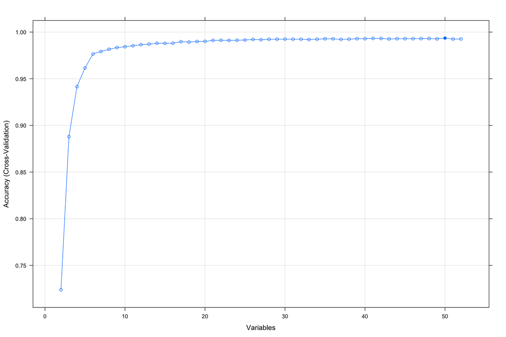

```r
## List the chosen features:

predictors <- predictors(results)[1:10] # We chose the first ten predictors with an accuracy of 0.9832. Less variables means more speed computationally speaking

## Plot the results:

plot(results, type=c("g", "o"))
```

### 4. Model estimate

```r
## Set the control parameters:

trainctrl <- trainControl(method = "cv",
                          number = 10,
                          allowParallel = TRUE,
                          verboseIter = TRUE)

## Fit random forest model:

ModFit <- train(classe ~ roll_belt + yaw_belt + magnet_dumbbell_z + magnet_dumbbell_y + pitch_belt + pitch_forearm + roll_forearm + accel_dumbbell_y + roll_dumbbell + roll_arm, method = "rf", data = training, trControl = trainctrl)
ModFit$finalModel
```

```
##
## Call:
##  randomForest(x = x, y = y, mtry = param$mtry)
##                Type of random forest: classification
##                      Number of trees: 500
## No. of variables tried at each split: 2
##
##         OOB estimate of  error rate: 1.32%
## Confusion matrix:
##      A    B    C    D    E class.error
## A 3330   15    1    2    0 0.005376344
## B   18 2217   34    9    1 0.027204914
## C    0   10 2024   19    1 0.014605648
## D    0    2   22 1904    2 0.013471503
## E    0    5    6    8 2146 0.008775982
```

```r
## Compare training predictions with testing predictions:

predTesting <- predict(ModFit, newdata = testing)

## Calculate confusion matrix:

M1 <- confusionMatrix(predTesting, testing$classe)

## Print out-of sample accuracy:

M1$overall[1] # 0.98. It means we got a very accurate estimate :)
```

```
##  Accuracy
## 0.9824114
```

```r
## Predict on validation data:

predValidation <- predict(ModFit, newdata = validation)
predValidation
```

```
##  [1] B A B A A E D B A A B C B A E E A B B B
## Levels: A B C D E
```

```r
## Stop cluster for multiple core computing:

stopCluster(cl)
```

### 5. Submission file

```r
pml_write_files = function(x){
  n = length(x)
  for(i in 1:n){
    filename = paste0("problem_id_",i,".txt")
    write.table(x[i],file=filename,quote=FALSE,row.names=FALSE,col.names=FALSE)
  }
}

pml_write_files(predValidation)
```